# Actividad 3: Analisis descriptivo e inferencial

Gonzalo Mellizo-Soto Diaz

12 de diciembre, 2018

**Pasos previos**

Cargamos el fichero y obervamos las variables

```r
fumadores <- read.csv('Fumadores_clean_5Y_1.csv')
head(fumadores)
```

```
##   Sex Sport Years Cig    PC                  City Weight Age Height  PC5Y
## 1   M     N    25  10 2.579             Barcelona     65  49    171 2.529
## 2   F     N    18  32 1.557              Terrassa     65  35    166 1.444
## 3   M     E     0   0 3.747             La Bisbal     69  38    175 3.730
## 4   M     S    25  14 2.762                Blanes     70  55    176 2.670
## 5   M     N     0   0 3.487 Sant Boi de Llobregat     72  55    178 3.487
## 6   F     E     0   0 4.075             Barcelona     64  42    165 4.052
```

# 1. Modelo de regresión lineal

*Primeramente, estudiaremos la posible asociación entre la capacidad pulmonar y algunas características de cada individuo.*

## 1.1. Modelo de regresión lineal múltiple (regresores cuantitativos)

*Estimar por mínimos cuadrados ordinarios un modelo lineal que explique la capacidad pulmonar (PC) de un individuo en función de tres factores cuantitativos: el peso (Weight), el número de cigarrillos que fuma al dia (Cig), y el número de años que hace que fuma (Years)*

*Evaluar la bondad de ajuste a través del coeficiente de determinación (R^2). Podéis usar la instrucción de R ´lm´*

*Ademas, evaluar si alguno de los regresores tiene influencia significativa (p-valor del contraste individual inferior al 5 %)*

*Observa que, a diferencia de Weight, no se ha añadido al modelo de regresión la variable Height, ¿desde el punto de vista de la calidad del modelo de regresión, puedes indicar una razón que justifique el no hacerlo?*

Lo primero es realizar la regresión lineal utilizando las variables mencionadas:

```r
lm_fumadores <- lm(PC ~ Weight+Cig+Years, data = fumadores)
lm_fumadores
```

```
##
## Call:
## lm(formula = PC ~ Weight + Cig + Years, data = fumadores)
##
## Coefficients:
## (Intercept)       Weight          Cig        Years
##    3.677888     0.001283    -0.032711    -0.023139
```

Una vez tenemos el modelo podemos obteber el coeficiente de determinación, los p-valores individuales:

```r
summary(lm_fumadores)
```

```
##
## Call:
## lm(formula = PC ~ Weight + Cig + Years, data = fumadores)
##
## Residuals:
##      Min       1Q   Median       3Q      Max
## -0.97891 -0.18424 -0.01939  0.19799  0.78591
##
## Coefficients:
##              Estimate Std. Error t value Pr(>|t|)
## (Intercept)  3.677888   0.284701  12.918   <2e-16 ***
## Weight       0.001283   0.004178   0.307    0.759
## Cig         -0.032711   0.001923 -17.008   <2e-16 ***
## Years       -0.023139   0.001583 -14.613   <2e-16 ***
## ---
## Signif. codes:  0 '***' 0.001 '**' 0.01 '*' 0.05 '.' 0.1 ' ' 1
##
## Residual standard error: 0.2734 on 296 degrees of freedom
## Multiple R-squared:  0.812,  Adjusted R-squared:  0.8101
## F-statistic: 426.3 on 3 and 296 DF,  p-value: < 2.2e-16
```

Coeiciente de determinación

```r
print(paste0("El coeficiente de determinación es: ", summary(lm_fumadores)$r.squared))
```

```
## [1] "El coeficiente de determinación es: 0.812046646998736"
```

Calculándolo sin utilizar el summary sería de la sigueinte manera:

```r
cor(fumadores$PC, lm_fumadores$fitted.values)^2
```

```
## [1] 0.8120466
```

Para obtener los p-valores individuales volvemos a utilizar el summary:

```r
summary(lm_fumadores)$coefficients
```

```
##                 Estimate  Std. Error     t value     Pr(>|t|)
## (Intercept)  3.677888473 0.284701405  12.9184065 1.399682e-30
## Weight       0.001282633 0.004178158   0.3069854 7.590704e-01
## Cig         -0.032711429 0.001923315 -17.0078405 1.000672e-45
## Years       -0.023138990 0.001583491 -14.6126397 8.768610e-37
```

En concreto:

```r
summary(lm_fumadores)$coefficients[2:4, 4]
```

```
##       Weight          Cig        Years
## 7.590704e-01 1.000672e-45 8.768610e-37
```

La siguientes variables tienen p-valores menores a 5%:

```r
summary(lm_fumadores)$coefficients[2:4, 4] < 0.05
```

```
## Weight    Cig  Years
##  FALSE   TRUE   TRUE
```

No se ha incluido la variable Height debido a la correlación que mantienen las dos variables es muy alta y desde el puto de vista estádistico, para realizar un buen modelo necesitamos que las variables sean independientes:

```r
cor(fumadores$Height, fumadores$Weight)
```

```
## [1] 0.9414455
```

## 1.2. Modelo de regresión lineal múltiple (regresores cuantitativos y cualitativos)

*Estimar por mínimos cuadrados ordinarios un modelo lineal que explique la capacidad pulmonar (PC) de un individuo en función de cinco regresores. Además de los tres anteriores (Years, Cig y Weight) ahora se añade las variables Sex y Sport. Usar como categoría de referencia de la variable Sex la categoria “F” y de la variable Sport la categoria “N” (para ello usar la función relevel() ). Se pueden definir nuevas variables, SexR y SportR, para esta nueva reordenación.*

*Evaluar la bondad del ajuste a través del coeficiente de determinación (R2) y comparar el resultado de este modelo con el obtenido en el apartado 1.1. Podéis usar la instrucción de R lm y usar el coeficiente R-cuadrado ajustado en la comparación. Interpretar también el significado de los coeficientes obtenidos y su significación estadística.*

Creamos las nuevas variables y comprobamos su reordenación

```r
fumadores$SportR <- relevel(fumadores$Sport, 'N')
fumadores$SexR <- relevel(fumadores$Sex, 'F')
levels(fumadores$SportR)
```

```
## [1] "N" "E" "R" "S"
```

```r
levels(fumadores$Sport)
```

```
## [1] "E" "N" "R" "S"
```

```r
levels(fumadores$SexR)
```

```
## [1] "F" "M"
```

```r
levels(fumadores$Sex)
```

```
## [1] "F" "M"
```

Entrenamos el nuevo modelo:

```r
fumadores_lm_5 <- lm(PC ~ Years + Cig + Weight + SexR + SportR, fumadores)
summary(fumadores_lm_5)
```

```
##
## Call:
## lm(formula = PC ~ Years + Cig + Weight + SexR + SportR, data = fumadores)
##
## Residuals:
##      Min       1Q   Median       3Q      Max
## -0.73530 -0.10739 -0.00663  0.10509  0.48296
##
## Coefficients:
##              Estimate Std. Error t value Pr(>|t|)
## (Intercept)  3.561531   0.236800  15.040  < 2e-16 ***
## Years       -0.022633   0.001065 -21.249  < 2e-16 ***
## Cig         -0.034035   0.001293 -26.315  < 2e-16 ***
## Weight      -0.000601   0.003599  -0.167 0.867511
## SexRM        0.102336   0.027373   3.739 0.000223 ***
## SportRE      0.565597   0.032939  17.171  < 2e-16 ***
## SportRR      0.370267   0.031566  11.730  < 2e-16 ***
## SportRS      0.199592   0.025917   7.701 2.11e-13 ***
## ---
## Signif. codes:  0 '***' 0.001 '**' 0.01 '*' 0.05 '.' 0.1 ' ' 1
##
## Residual standard error: 0.1827 on 292 degrees of freedom
## Multiple R-squared:  0.9172, Adjusted R-squared:  0.9152
## F-statistic: 462.2 on 7 and 292 DF,  p-value: < 2.2e-16
```

Coficiente de determinación

```r
summary(fumadores_lm_5)$r.squared
```

```
## [1] 0.9172211
```

En este caso nos encontramos con un valor más alto que el obtenido en el apartado 1.1 en más de una decima( 0.812 vs 0.917). A priori esta información sugiere que nos encontramos ante un modelo mejor y más robusto a la hora de determinar la variable dependiente.

Como se puede apreciar en los coeficientes aparecen los niveles que se incluyen en las nuevas variables, por ello vamos a recrdar las variables, para “Sex” F = Female (mujer) M = Male (hombre) en el caso de “Sport” el significado es el siguiente N = None (Nada), S = Sometimes (de vez en cuando), R = Regularly (Regularmete) y E = Everyday (todos los días).

En la variable Sport podemos identificar lo siguiente:

- Practicar ejercicio todos los días aumenta significativamente la capacidad pulmonar (SportRE)
- Realizar algo de ejercicio mejora la capacidad pulmonar
- El coeficiente decrece si se practica menos deporte

En la variable Sex se puede observar que los hombres (SexRM) aumentan positivamente la capacidad pulmonar.

La cantidad de años y el número de cigarrillos al días disminuyen significativamente la capacidad pulmonar.

## 1.3. Efectuar una predicción de la capacidad pulmonar con los dos modelos

*Suponer un hombre de Lleida de 30 años de edad que hace deporte regularmente, de peso 68 kg y de altura 175 cm que fuma desde hace 15 años de 10 cigarros al dia.*

*Realizar la predicción de la capacidad pulmonar (PC) con los dos modelos. Interpretar los resultados.*

Creamos la nueva observación en un nuevo dataframe

```r
hulio <- data.frame(Years = 15, SportR = factor('R', levels = c("N","E","R","S")),
                    Weight = 68, Height = 175, Age = 30, Cig = 10, City = 'Lleida',
                    SexR = factor('M', levels = c('F', 'M')))
```

Efecuamos ambas predicciones:

```r
print(paste0('La predicción del primer modelo es: ',round(predict.lm(lm_fumadores, hulio), 3)))
```

```
## [1] "La predicción del primer modelo es: 3.091"
```

```r
print(paste0('La predicción del segundo modelo es: ',round(predict.lm(fumadores_lm_5, hulio), 3)))
```

```
## [1] "La predicción del segundo modelo es: 3.313"
```

Para el primer modelo la interpretación es la siguiente:

```r
round(3.677888 +  0.001283*68 + 10*(-0.032711) + 15*(-0.023139), 3)
```

```
## [1] 3.091
```

Para el segundo tenemos lo siguiente:

```r
round(3.561531 +  (-0.000601)*68 + 10*(-0.034035) + 15*(-0.022633) +  0.370267 + 0.102336, 3)
```

```
## [1] 3.313
```

en este caso los cigarrillos y los años de fumar afectan negativamente, pero al tener en cuenta de que se trata de un hombre y que realiza ejercicio regularmente, la capacidad pulmonar aumenta en consecuencia mitigando los años de fumador y los cigarrillos en cierta medida.

# 2. Modelo de regresión logística

*Se desea evaluar la calidad predictiva de la capacidad pulmonar así como de otras variables presentes en el estudio respecto a la predicción de ser fumador. Por tanto, se evaluará la probabilidad de que un individuo sea fumador.*

*Para evaluar esta probabilidad se aplicará un modelo de regresión logística, donde la variable depediente será una variable binaria que indicará si el individuo es fumador. Se usará la muestra disponible para estimar el modelo con las mismas variables que en el modelo 1.1.*

## 2.1. Estimación de un modelo de regresión logística

*El primer paso será crear una variable binaria (smoker) que indique la condición de fumador (smoker = 1) o no fumador(smoker = 0). Estimar el modelo de regresión logística donde la variable dependiente es “smoker” y las explicativas son la capacidad pulmonar (PC), Weight y SexR*

*Evaluar si alguno de los regresores tiene influencia significativa (p-valor del contraste individual inferior al 5 %)*

*Evaluando los resultados, ¿se puede decir que un individuo con capacidad pulmonar reducida tiene mayor probabilidad de ser fumador?*

*¿Se puede decir que ser mujer aumenta la probabilidad de ser fumador?*

Para crear la variable uilizaremos la variable “Years”, donde aquellas personas con valores distintos de cero se consideran fumadoras (se podría también utilizar Cig para ello dado que la cantidad de ceros es igual y coinciden en posición)

```r
fumadores$smoker <- fumadores$Years
fumadores$smoker[fumadores$smoker > 0] <- 1
table(fumadores$smoker)
```

```
##
##   0   1
## 169 131
```

Como vemos tenemos 169 no fumadores y 131 fumadores. Una vez tenemos la variable generamos el modelo:

```r
glm_fumadores <- glm(smoker ~ PC + Weight + SexR,family = binomial, data = fumadores)
summary(glm_fumadores)
```

```
##
## Call:
## glm(formula = smoker ~ PC + Weight + SexR, family = binomial,
##     data = fumadores)
##
## Deviance Residuals:
##      Min        1Q    Median        3Q       Max
## -1.47787  -0.31210  -0.04843   0.04271   3.13797
##
## Coefficients:
##             Estimate Std. Error z value Pr(>|z|)
## (Intercept) 38.51385    7.64106   5.040 4.65e-07 ***
## PC          -9.50804    1.36436  -6.969 3.20e-12 ***
## Weight      -0.09876    0.08155  -1.211    0.226
## SexRM        0.76825    0.64182   1.197    0.231
## ---
## Signif. codes:  0 '***' 0.001 '**' 0.01 '*' 0.05 '.' 0.1 ' ' 1
##
## (Dispersion parameter for binomial family taken to be 1)
##
##     Null deviance: 411.06  on 299  degrees of freedom
## Residual deviance: 107.87  on 296  degrees of freedom
## AIC: 115.87
##
## Number of Fisher Scoring iterations: 8
```

La variable con más influencia se trata de la capacidad pulmonar (PC) dado que tiene un valor muy inferior al 5%, mientra que las otras lo superan.

Según los coeficientes podemos observar que el valor negativo nos indica que a mayor capacidad pulmonar menor probabilidad hay de ser fumador.

## 2.2. Predicción en el modelo lineal generalizado (modelo de regresión logística)

*Usando el modelo anterior, calculad la probabilidad de ser fumador para un hombre que tiene una capacidad pulmonar de 3.75 l/s, un peso de 68 kg y altura de 175 cm.*

Creamos la observación:

```r
glm_test <- data.frame(Weight = 68, SexR = factor('M', levels = c('F', 'M')), PC = 3.75)
print(paste0("La probabilidad de que sea fumador es: ",
             round(predict.glm(glm_fumadores, glm_test, type = "response")*100,2)
             ,'%')
      )
```

```
## [1] "La probabilidad de que sea fumador es: 4.36%"
```

## 2.3. Mejora del modelo

*Buscar un modelo mejor al anterior añadiendo más variables explicativas. Se realizarán las siguientes pruebas:*

- *Modelo regresor que añade al anterior la variable edad (Age).*
- *Modelo regresor que añade la variable SportR.*
- *Modelo regresor que añade Age y SportR.*

*Decidir si se prefiere el modelo inicial o bien uno de los modelos con Age, con SportR, o con ambas. El criterio para decidir el mejor modelo es AIC. Cuanto más pequeño es AIC mejor es el modelo*

Entrenamos los modelos y vemos los resumenes:

```r
glm_fumadores_A <- glm(smoker ~ PC + Weight + SexR + Age,family = binomial, data = fumadores)
glm_fumadores_S <- glm(smoker ~ PC + Weight + SexR + SportR,family = binomial, data = fumadores)
glm_fumadores_AS <- glm(smoker ~ PC + Weight + SexR + Age + SportR,family = binomial, data = fumadores)
summary(glm_fumadores_A)
```

```
##
## Call:
## glm(formula = smoker ~ PC + Weight + SexR + Age, family = binomial,
##     data = fumadores)
##
## Deviance Residuals:
##      Min        1Q    Median        3Q       Max
## -2.05290  -0.06361  -0.00431   0.01063   2.84865
##
## Coefficients:
##              Estimate Std. Error z value Pr(>|z|)
## (Intercept)  68.66375   14.34683   4.786 1.70e-06 ***
## PC          -14.39062    2.65981  -5.410 6.29e-08 ***
## Weight       -0.11440    0.10560  -1.083    0.279
## SexRM         1.24369    0.89143   1.395    0.163
## Age          -0.29822    0.06635  -4.494 6.98e-06 ***
## ---
## Signif. codes:  0 '***' 0.001 '**' 0.01 '*' 0.05 '.' 0.1 ' ' 1
##
## (Dispersion parameter for binomial family taken to be 1)
##
##     Null deviance: 411.062  on 299  degrees of freedom
## Residual deviance:  56.679  on 295  degrees of freedom
## AIC: 66.679
##
## Number of Fisher Scoring iterations: 9
```

```r
summary(glm_fumadores_S)
```

```
##
## Call:
## glm(formula = smoker ~ PC + Weight + SexR + SportR, family = binomial,
##     data = fumadores)
##
## Deviance Residuals:
##     Min       1Q   Median       3Q      Max
## -2.0920  -0.1017  -0.0111   0.0012   3.4450
##
## Coefficients:
##             Estimate Std. Error z value Pr(>|z|)
## (Intercept)  67.3890    16.7310   4.028 5.63e-05 ***
## PC          -18.5231     3.5122  -5.274 1.34e-07 ***
## Weight       -0.1098     0.1588  -0.691   0.4893
## SexRM         1.7538     1.1346   1.546   0.1221
## SportRE       9.9092     2.1297   4.653 3.27e-06 ***
## SportRR       7.2364     1.7681   4.093 4.26e-05 ***
## SportRS       2.9985     1.2650   2.370   0.0178 *
## ---
## Signif. codes:  0 '***' 0.001 '**' 0.01 '*' 0.05 '.' 0.1 ' ' 1
##
## (Dispersion parameter for binomial family taken to be 1)
##
##     Null deviance: 411.062  on 299  degrees of freedom
## Residual deviance:  40.261  on 293  degrees of freedom
## AIC: 54.261
##
## Number of Fisher Scoring iterations: 9
```

```r
summary(glm_fumadores_AS)
```

```
##
## Call:
## glm(formula = smoker ~ PC + Weight + SexR + Age + SportR, family = binomial,
##     data = fumadores)
##
## Deviance Residuals:
##      Min        1Q    Median        3Q       Max
## -2.04847  -0.03630  -0.00360   0.00222   2.36582
##
## Coefficients:
##             Estimate Std. Error z value Pr(>|z|)
## (Intercept)  86.9566    25.9884   3.346 0.000820 ***
## PC          -18.7665     4.4594  -4.208 2.57e-05 ***
## Weight       -0.2067     0.2046  -1.010 0.312354
## SexRM         2.5902     1.4862   1.743 0.081361 .
## Age          -0.2912     0.1069  -2.724 0.006451 **
## SportRE       7.2214     1.9630   3.679 0.000234 ***
## SportRR       5.1093     2.1758   2.348 0.018862 *
## SportRS       2.3166     1.4635   1.583 0.113436
## ---
## Signif. codes:  0 '***' 0.001 '**' 0.01 '*' 0.05 '.' 0.1 ' ' 1
##
## (Dispersion parameter for binomial family taken to be 1)
##
##     Null deviance: 411.062  on 299  degrees of freedom
## Residual deviance:  25.559  on 292  degrees of freedom
## AIC: 41.559
##
## Number of Fisher Scoring iterations: 10
```

A primera vista con los coeficientes se puede observar que se han introducido variables que añaden significación a los distintos modelos.

El siguiente paso es evaluar los modelos:

```r
print(paste0("El AIC del modelo inicial es: ", AIC(glm_fumadores)))
```

```
## [1] "El AIC del modelo inicial es: 115.874769201303"
```

```r
print(paste0("El AIC del modelo inicial + Age  es: ", AIC(glm_fumadores_A)))
```

```
## [1] "El AIC del modelo inicial + Age  es: 66.6790288664409"
```

```r
print(paste0("El AIC del modelo inicial + SportR es: ", AIC(glm_fumadores_S)))
```

```
## [1] "El AIC del modelo inicial + SportR es: 54.2610429316046"
```

```r
print(paste0("El AIC del modelo inicial + Age y SportR es: ", AIC(glm_fumadores_AS)))
```

```
## [1] "El AIC del modelo inicial + Age y SportR es: 41.5586883459927"
```

podemos observar como las nuevas variables aportan valor y ayudan a exlicar mejor la variable dependiente, sobretodo SportR y como su conjunto con Age, es capaz de disminuir a menos de la mitad del valor del modelo inicial de AIC. Por ello seleccionamos el que incluye ambas como el mejor modelo.

## 2.4. Calidad del ajuste

*Calcular la matriz de confusión del mejor modelo del apartado 2.3 suponiendo un umbral de discriminación del 70 %. Observad cuantos falsos negativos hay e interpretar qué es un falso negativo en este contexto. Hacer lo mismo con los falsos positivos.*

Dado que en el entrenamiento del modelo obtenemos los valores en fitted.values, podemos utilizar estos para generar el vector con los resultados utilizando un umbral del 70%.

```r
predictions <- glm_fumadores_AS$fitted.values
predictions <- ifelse(predictions > 0.7, 1, 0)
table(fumadores$smoker,predictions)
```

```
##    predictions
##       0   1
##   0 167   2
##   1   4 127
```

En este caso el modelo clasifica correctamente 167 de los 169 no fumadores y 127 fumadores de los 131. Dentro de la matriz de confusión podemos observar que nos encontramos con 2 falsos positivos, es decir, nos encontramos con dos personas que NO siendo fumadoras se han clasificado como fumadoras. Por otro lado, ocurre lo mismo con los falsos negativos, se han predecido 4 personas fumadoras como NO fumadoras. Ésta última parte nos puede indicar que somos más propensos a realizar errores tipo 2.

## 2.5. La selección de los individuos fumadores

*Establecer un nivel de probabilidad (umbral de discriminación) a partir del cual pensáis que el individuo tiene muchas posibilidades de ser un fumador, por ejemplo podéis escoger el 70 %. Comparar el nivel de probabilidad que da el modelo con el valor de capacidad pulmonar (PC) del individuo. Identificar los individuos que no se comportan según lo esperado, es decir tienen elevada capacidad pulmonar y el modelo los clasifica como fumadores y reportar los valores de probabilidad de ser fumador y de PC. Utilizar como umbral para declarar un individuo con PC elevado el cuartil tercero de la variable PC.*

En este caso se va a definir una función para realizar el estudio gráfico según el umbral preferido (moverá la línea dentro del gráfico). En este caso se representan dos líneas, una indica el tercer cuartil de la variable (horizontal) y una segunda línea que muestra el umbral (vertical). Con ello se consiguen identificar las observaciones que cumplen esto en el recuadro superior derecho.

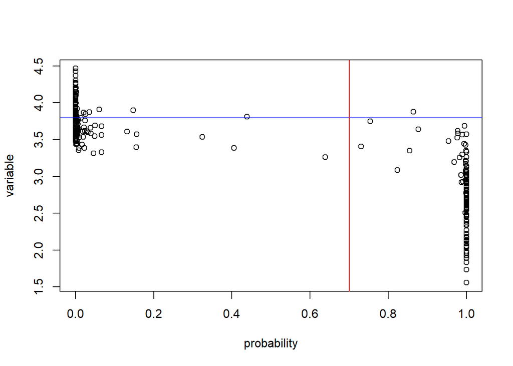

```
## [1] "Probability: 0.864825808790824"
## [1] "Value: 3.876"
```

```r
plotSmokersThreshold <- function(probability, variable, threshold){
  plot(probability, variable)
  abline(h=quantile(variable)[4], col='blue')
  abline(v=threshold, col='red')
  ind <- (probability > threshold) & (variable > quantile(variable)[4])
  print(paste0("Probability: ", probability[ind]))
  print(paste0("Value: ", variable[ind]))
}

plotSmokersThreshold(glm_fumadores_AS$fitted.values, fumadores$PC, 0.7)
```

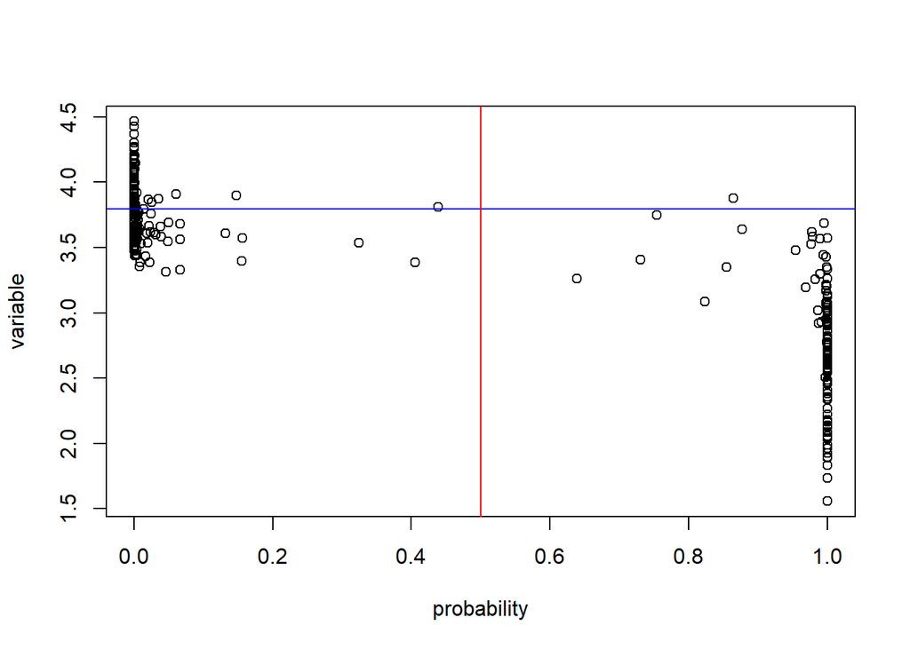

```
## [1] "Probability: 0.864825808790824"
## [1] "Value: 3.876"
```

```r
plotSmokersThreshold(glm_fumadores_AS$fitted.values, fumadores$PC, 0.5)
```

En ambos se puede observar como para umbrales mayores de 50% solo se aprecia una sola observación que siga este patrón el cúal tiene una capacidad pulmonar mayor al 3.8 y una probabilidad de ser fumador mayor del 80%. En el caso de que disminuyeramos el umbral por debajo del 40% podriamos encontrar otra observación que cumpla con lo dicho.

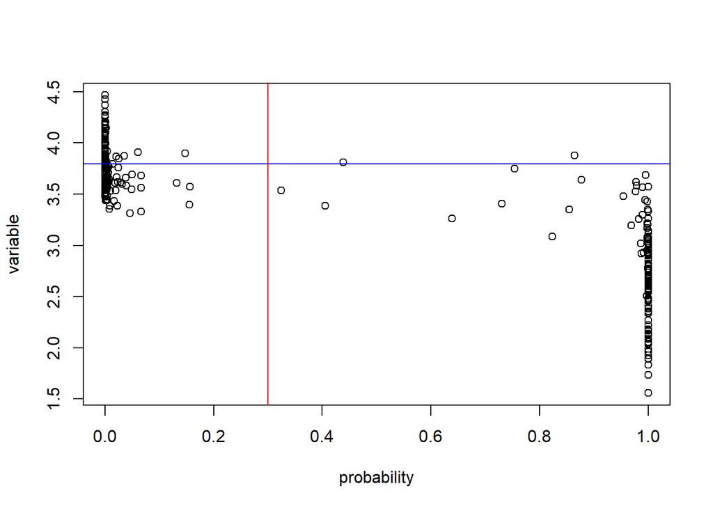

```
## [1] "Probability: 0.864825808790824" "Probability: 0.438526865358783"
## [1] "Value: 3.876" "Value: 3.808"
```

```r
plotSmokersThreshold(glm_fumadores_AS$fitted.values, fumadores$PC, 0.3)
```

## 2.6. Curva ROC

*Realizar el dibujo de la curva ROC para representar la calidad del modelo predictivo obtenido. Se puede usar la librería pROC y la instrucción rocy, finalmente, el plot del objeto resultante . Calcular AUROC usando también este paquete con la función auc() donde debéis pasar el nombre del objeto roc.*

*Interpretar el resultado*

```r
glm_roc <- roc(fumadores$smoker,predictions)
glm_roc
```

```
##
## Call:
## roc.default(response = fumadores$smoker, predictor = predictions)
##
## Data: predictions in 169 controls (fumadores$smoker 0) < 131 cases (fumadores$smoker 1).
## Area under the curve: 0.9788
```

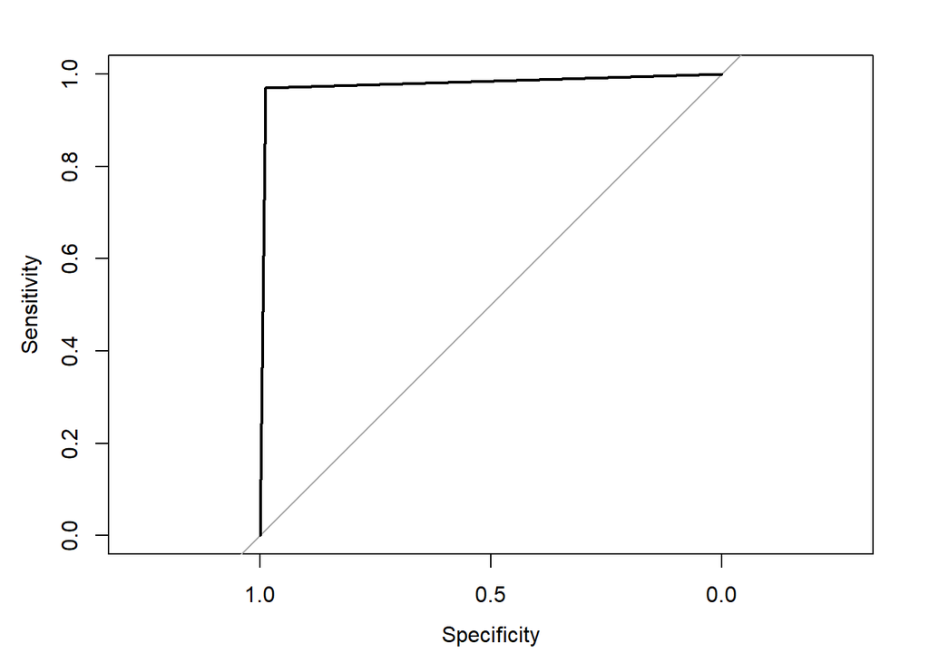

```r
plot(glm_roc)
```

```r
auc(glm_roc)
```

```
## Area under the curve: 0.9788
```

Podemos observar como le valor se encuentra muy cercano a uno, por lo que se puede asumir que se ha realizado un buen mocelo que es capaz de realizar una clasificación muy precisa (siendo 1 una clasificación perfecta y 0.5 aleatoria).

Por otro lado, puede parecer un poco complicado interpretar un resultado donde la aleatoriedad es 0.5 y la perfección es 1, por ello se puede transformar al índice GINI el cual devuelve un valor representado entre 0 y 1 y puede ayudarnos a la compresión de la AUROC (en este caso al estar muy cercano a 1 es simple observar que se trata de un buen modelo)

```r
print(paste0("GINI: ",auc(glm_roc)*2 - 1))
```

```
## [1] "GINI: 0.957631329328335"
```

# 3. Referencias

- Recursos de la asignatura
- [Coefficient of Determination](http://www.r-tutor.com/elementary-statistics/simple-linear-regression/coefficient-determination)
- [How to perform a Logistic Regression in R](https://www.r-bloggers.com/how-to-perform-a-logistic-regression-in-r/)
- [Type I and type II errors](https://en.wikipedia.org/wiki/Type_I_and_type_II_errors)
- [abline R function](http://www.sthda.com/english/wiki/abline-r-function-an-easy-way-to-add-straight-lines-to-a-plot-using-r-software)
- [R Markdown Cheat Sheet](https://www.rstudio.com/wp-content/uploads/2015/02/rmarkdown-cheatsheet.pdf)